# Final Report

*Research Question: Our research question is: Are there any notable patterns in liquor sales based on educational attainment levels within Iowa communities? By addressing this question, we hope to answer if areas with higher levels of education exhibit different purchasing behaviors compared to areas with lower educational attainment*

# Introduction

This project aims to aid the Director of the Iowa Public Health Department of Iowa in their public health advertisement campaign aimed at reducing excessive alcohol consumption. Our analyses will be helpful in better understanding *if there is any underlying relationship between education attainment levels (high school degree and bachelor degree) and liquor sales in the state of Iowa*. If analyses supports that there is a significant relationship between education attainment levels and liquor sales, this information can be used to help decide which counties need targeted campaigns and resource allocation most immediately based on region-level education attainment level data. We will also investigate how and if other factors impact liquor sale trends (i.e. time, socioeconomic factors, demographic factors) and offer this information to the Director of Public Health so that they are aware of other relevant factors linked to liquor sales in the state of Iowa. This information will be valuable to the Director of the Public Health Department as they attempt to target specific regions that may be in need targeted campaigns and resource allocation with the hopes of combating excessive alcohol consumption. Targeted anti-excessive drinking campaigns and resource allocations in “at-risk” regions could improve the health and safety of Iowa residents.

# Data Summary

A few main data sources were considered throughout data analysis:

## Brief Data Summary

Education attainment levels are the main variable that we are analyzing in relation to liquor sales in the state of Iowa.

These are the 10 counties with the **lowest** high school degree attainment rates:

| County | High School Degree Attainment Rate |
| --- | --- |
| Buena Vista | 0.779 |
| Crawford | 0.818 |
| Davis | 0.821 |
| Louisa | 0.843 |
| Marshall | 0.852 |
| Clarke | 0.855 |
| Woodbury | 0.877 |
| Wapello | 0.879 |
| Osceola | 0.881 |
| Allamakee | 0.884 |

These are the 10 counties with the **lowest** Bachelor’s Degree attainment rates:

| County | Bachelor’s Degree Attainment Rate |
| --- | --- |
| Wayne | 0.143 |
| Taylor | 0.148 |
| Osceola | 0.150 |
| Crawford | 0.151 |
| Tama | 0.156 |
| Monona | 0.157 |
| Clarke | 0.159 |
| Pocahontas | 0.159 |
| Wright | 0.163 |
| Van Buren | 0.164 |

[output not shown]

|  | Minimum | Q1 | Median | Mean | Q3 | Max | IQR |
| --- | --- | --- | --- | --- | --- | --- | --- |
| High School Degree | 0.7790 | 0.9058 | 0.9260 | 0.9193 | 0.9367 | 0.9680 | 0.0309 |
| Bachelor’s Degree | 0.1430 | 0.1842 | 0.2020 | 0.2255 | 0.2347 | 0.5430 | 0.0505 |

From this summary, we can conclude that, on average, counties in Iowa have higher rates of high school graduates compared to residents with bachelor’s degrees.

The small IQRs for both education attainment levels suggests that the middle 50% of counties have similar education attainment levels. However, the max value for the Bachelor’s Degree data suggests that there may be some counties that have notably higher bachelor’s degree attainment levels.

# Data Analytics

Linear regression analyses were performed on the data set that considered gin sales in Iowa from 2016-2017. The intention of the analysis was to establish whether or not there is a statistically significant relationship between liquor sales (in both dollars and volume) in Iowa and time. It was established that there is indeed a significant relationship between liquor sales and time and that liquor sales are decreasing as time increases.

A linear regression analysis revealed that there is a significant relationship between liquor sales in dollars and time. The model was able to fit a decreasing straight line between monthly gin sales (in dollars) across the last two years. The linear model suggests that on average, there is a $268.80 decrease in gin sales in the state of Iowa. The date coefficient has a p-value of 0.0319, which is less than 0.05, thus signifying a statistically significant relationship between time and gin sales. The R-squared value is 0.1927, which suggests that approximately 19% of the variance in total sales (in dollars) is explained by time. This suggests that liquor sales (in dollars) is somewhat dependent on the variable of time.

### Linear Regression Model examining the relationship between time and gin sales (in dollars)

[output not shown]

### Linear Regression Model examining the relationship between time and gin sales (in volume)

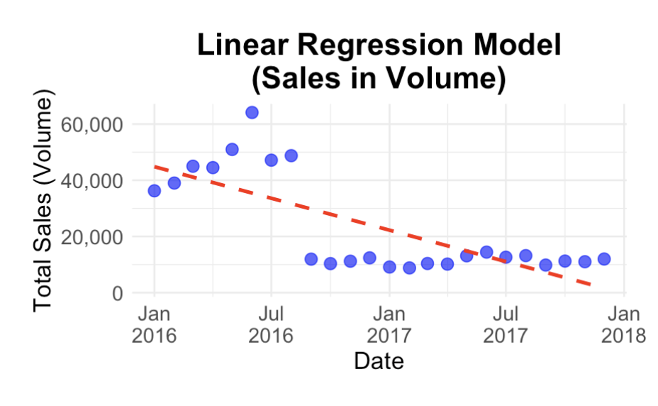

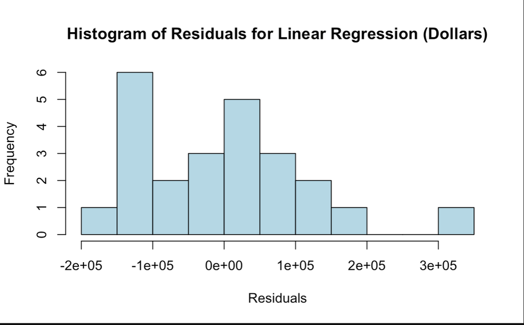

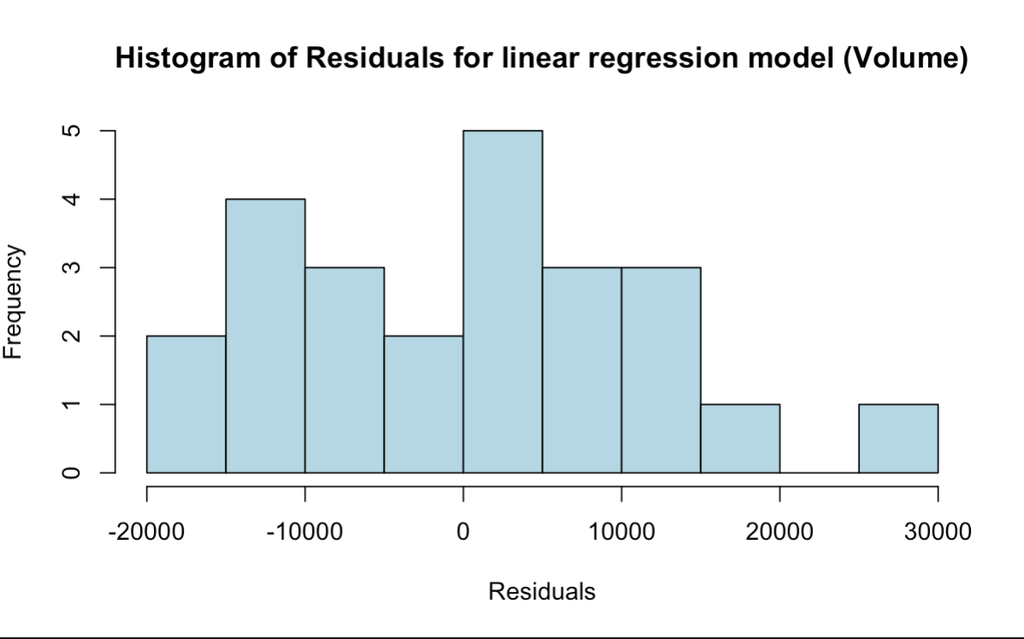

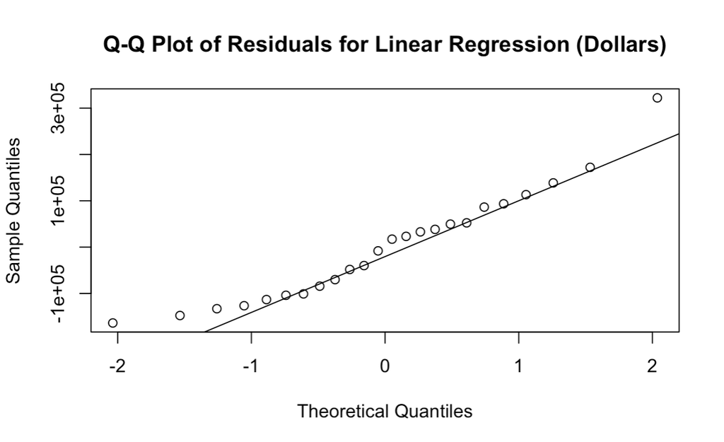

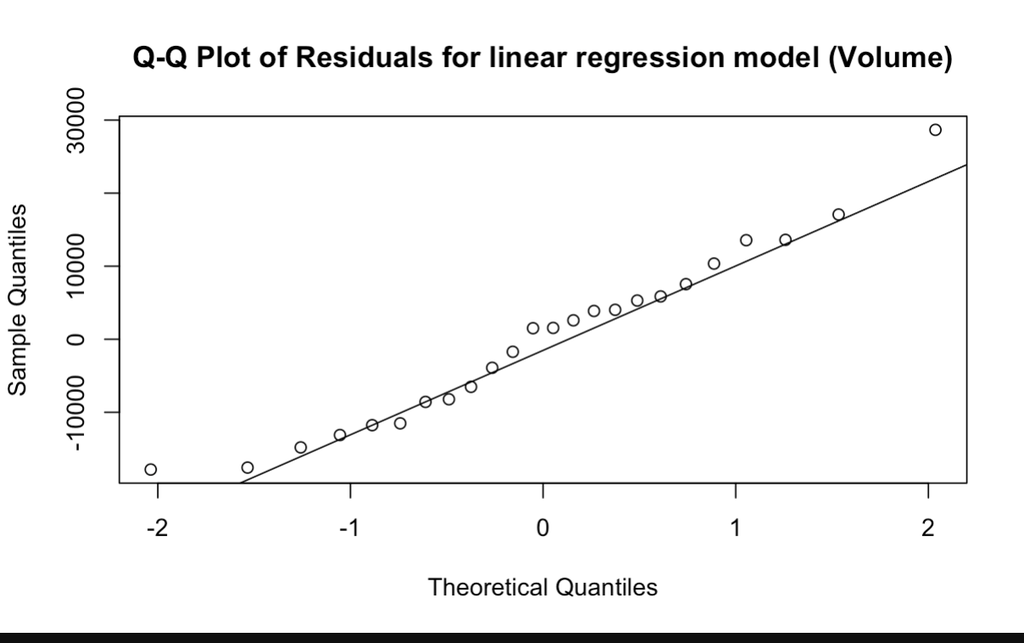

Both linear regression models suggest that historically liquor sales have decreased as a result of time progressing. This statistical significance of these models suggest that sales measured in both dollars and volume will continue to decrease as time increases. This information may be useful for the policy maker for multiple reasons. This information is valuable as it confirms that historically time does have an impact on liquor sales. The director of public health should be made aware of as many factors as possible that influence liquor sales in order to best make a plan to decrease liquor consumption. Another reason this information is valuable as it suggests that any resource allocation or targeted campaigning that the department of public health has applied from 2016 to 2017 was potentially helpful as gin sales did decrease in this time span. This may encourage the policy maker to continue certain efforts (i.e. continue targeting the specific regions that have been targeted during this time or continue a certain kind of resource allocation) that have already been applied in hopes of continuing to decrease liquor sales in Iowa.

### Linear Regression Model testing the highschool graduation and bachelor degree on the liquor sales dollars

By examining county-level data including liquor sales dollars, high school graduation rates, and bachelor’s degree rates, how different levels of educational attainment influence liquor sales was able to be assessed. The linear regression analysis indicates that both high school graduation and bachelor’s degree rates have a positive effect on liquor sales. It was determined that across all counties, a 1-unit increase in high school graduation rates results in an average increase of $319.20 of all liquor sales. Furthermore, the linear regression analyses suggests that a 1-unit increase in bachelor’s degree rates is associated with an average increase of $509.20 of total liquor sales across Iowa.

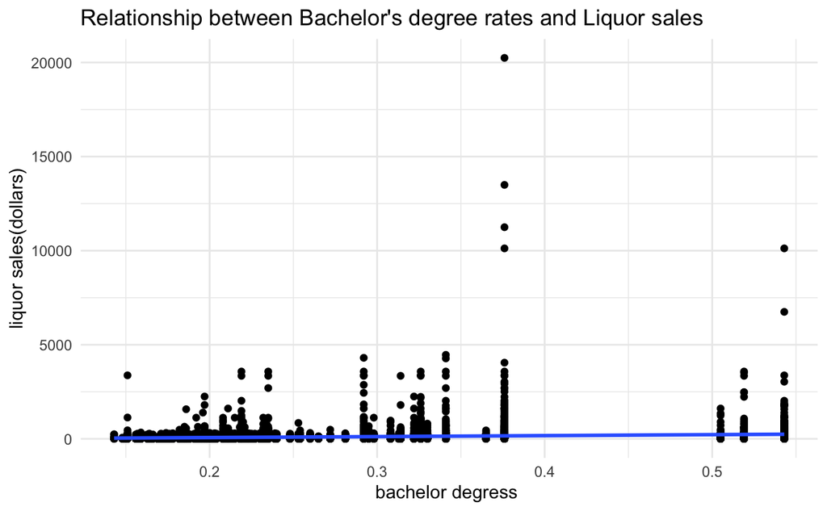

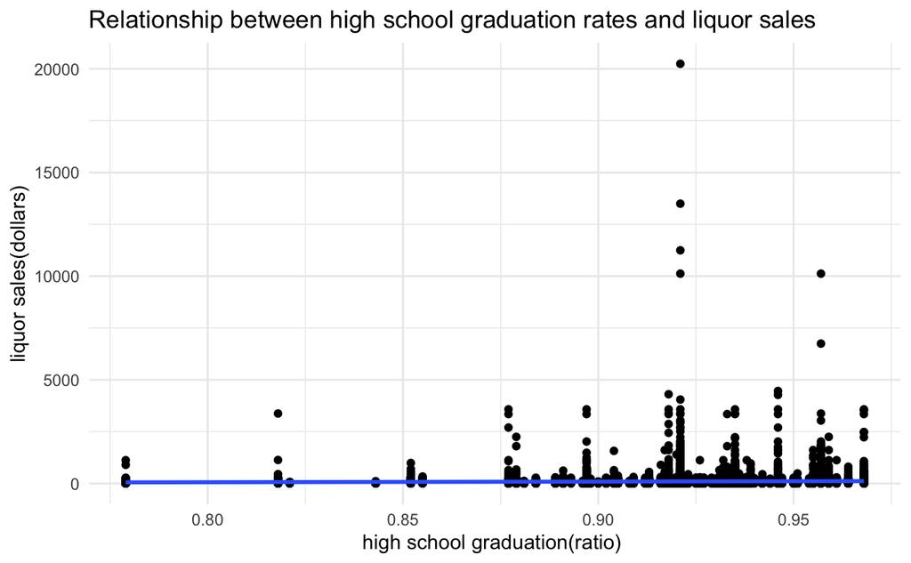

Comparing the two graphs, we can analyze the characteristics of high school graduation and bachelor’s degrees. The distribution of high school graduation percentages is skewed to the left, indicating that most people in all counties in Iowa have a graduation rate of over 90-95%. This is reflected in the clustering of data points around the 0.90-0.95 range. On the other hand, the distribution of bachelor’s degrees is skewed to the right, suggesting that most people in these counties do not have bachelor’s degrees. The number of data points sharply decreases when the bachelor’s degree rate exceeds 0.3, while at the same time, there is an increase in the cumulative liquor sales.

Regression analysis of high school graduation and bachelor’s degree data helps uncover the relationship between liquor consumption and counties, differentiated by educational level. Defining specific thresholds for educational levels, such as lower high school graduation rates and higher bachelor’s degree rates within a county, can provide valuable insights for policymakers in designing tactics to address liquor consumption issues.

Conducting Welch two-sample t-tests on defined proportions with high or low levels of education allows for the analysis of the average educational level of a specific county and its correlation with liquor sales. This approach can help policymakers identify counties with particular educational profiles and examine their corresponding liquor sales numbers. By understanding how educational attainment relates to liquor sales, the director of public health can target interventions and educational campaigns more effectively.

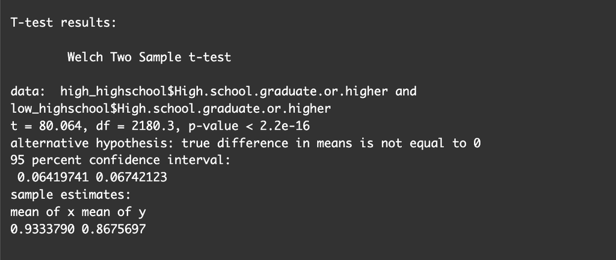

The process was similar for separating counties based on higher and lower bachelor’s degree rates, with a threshold set at 0.2. The resulting p-value was still smaller than the chosen significance level, indicating a significant difference in the proportion of bachelor’s degrees between the higher and lower bachelor degree groups. There are only 51 counties with bachelor’s degree rates higher than 0.2.

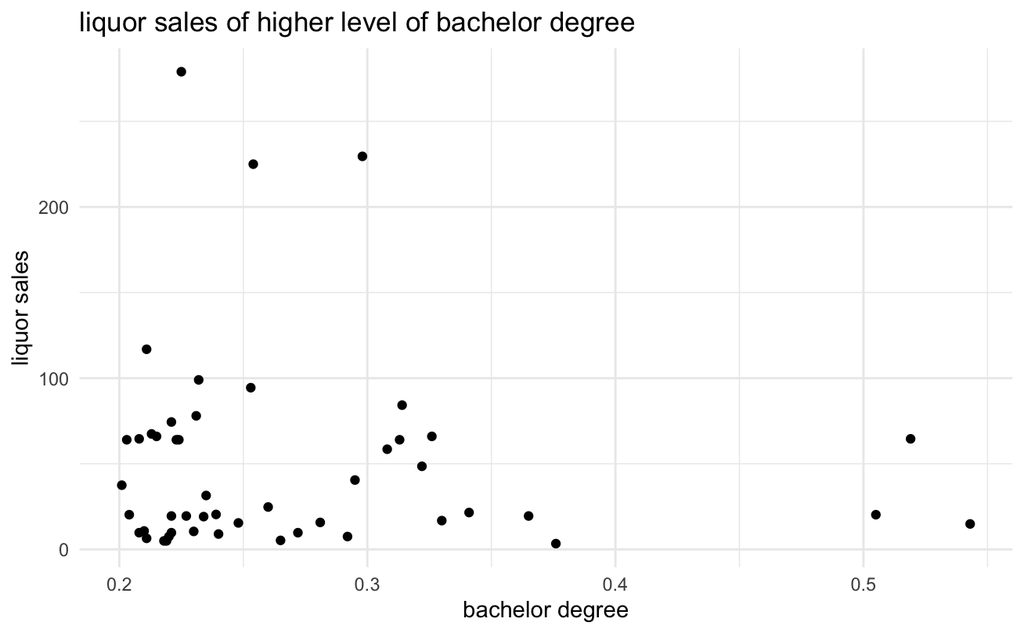

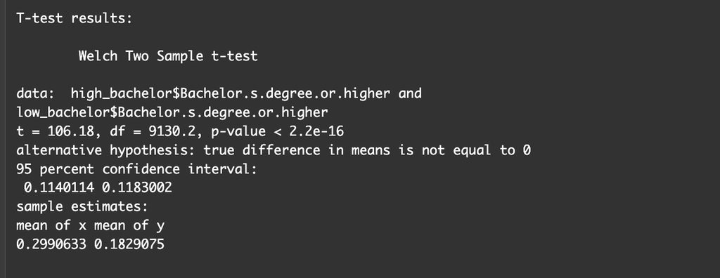

To make a more complete analyis, the plot of lower high school graduation ratio and liquor consumption could be compared as an opposite. There are only 19 counties that have the high school gradution lower than 0.9, and the liquor sales are relatively higher when high school gradution ratio is extremely low(0.8) and relatively average(0.9). From the previous distribution plot of high school, as the ratio increases, liquor sales increase either: it would be effective to surmise that the educational attainment is an essential estimator of liquor sales, but after setting the threshold and dividing counties into groups to explore liquor sales on higher/lower bachelor degree, higher/lower high school degree, the focus shift to find the liquor purchasing pattern on higher bachelor degree and lower high school degree including liquor retail price, subcategory.

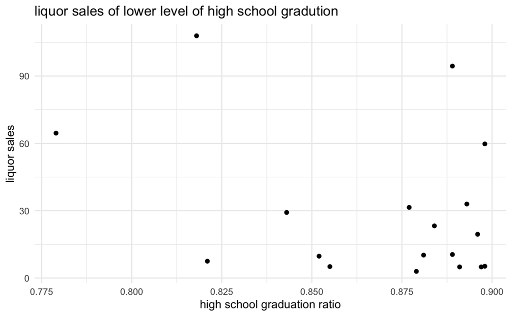

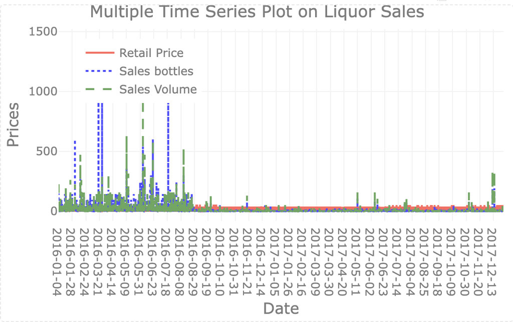

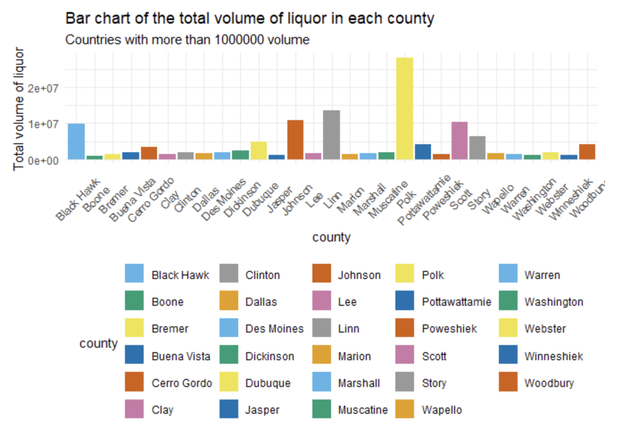

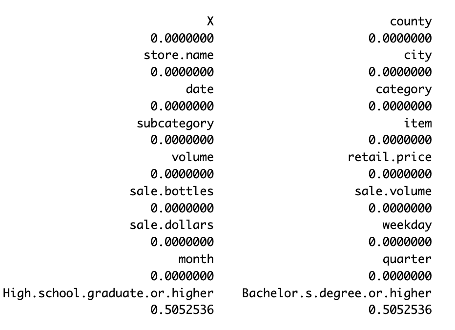

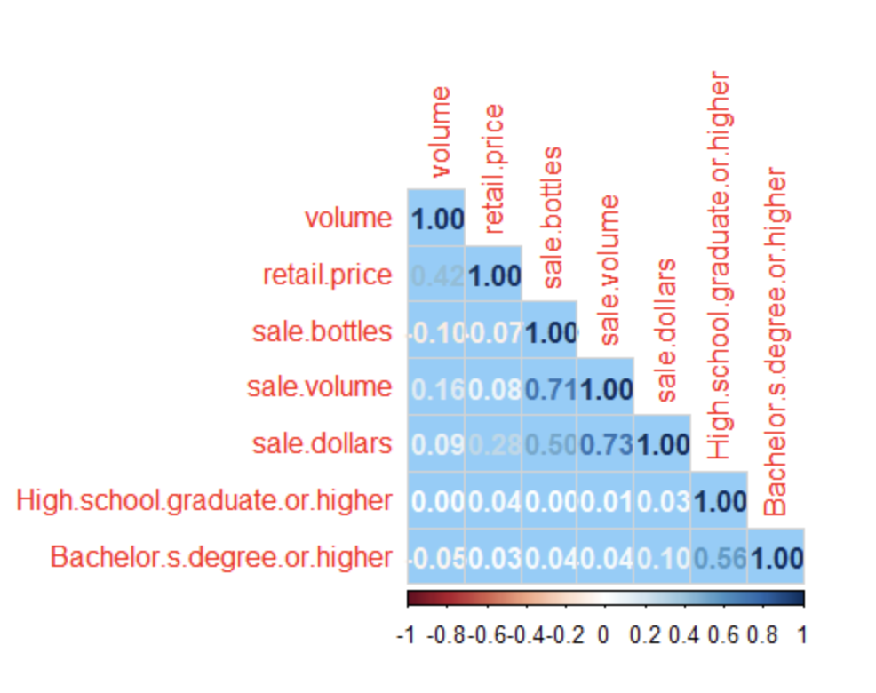

Based on the correlation analysis, we found that the percentage of individuals with at least a bachelor’s degree had a strong relationship with the percentage of high school graduates or higher, with a correlation coefficient of 0.56. This suggests that counties with higher levels of bachelor’s degree attainment tend to also have higher levels of high school graduation.

## Other Exploratory Analyses

There were a couple of exploratory analyses conducted on the data that we cannot include in our policy recommendation with full confidence but we believe may still be valuable to the policy maker.

An attempt was made to decompose the sales data into seasonal components to assess if seasonality is a factor that should be considered as the policy maker is developing targeted anti-drinking campaigns and resource allocation. However, the data was unable to be decomposed into seasonal components suggesting that seasonality should not be a consideration for the director of public health.

A forecasting analysis was conducted. The intention of this was to use various forecasting methods to estimate future gin liquor sales in the next two years. Doing this on a county by county basis would allow for the identification of “high risk” counties that are predicted to have the greatest increase in gin liquor sales. Identification of these high risk counties may be valuable information for the decision maker as these areas are at risk of increased alcohol consumption and should potentially be considered targets for resource allocation and targeted anti-drinking campaigns.

ARIMA and seasonal naive models were considered for this purpose. We hesitate to include the results from the seasonal naive model in our formal policy recommendation as seasonal naive models are quite naive models that simply consider the liquor sales from the previous seasonal period. However, we failed to identify seasonality in the data, so we expect these estimates to be poor. According to the seasonal naive model, the counties that are predicted to have the largest increase of gin sales in the next two years are:

```
"Woodbury"    "Winneshiek"  "Clay"        "Cerro Gordo" "Story"
```

The same approach was followed using ARIMA models. Though ARIMA models are more complex, we hesitate to formally includue the results from these models in our formal policy recommendation as many of the forecasts of gin sales in the 24 months were identical to the month before and the month after. This fixed, linear forecast is likely due to a lack of data points as we only have 24 months of data to work with and potentially also related to a lack of seasonality in the data. However, the ARIMA models were able to identify the five counties that are deemed “high risk” as they are predicted to have the largest increase in gin sales (in volume) in the next two years. These counties are:

```
 "Black Hawk" "Webster"  "Clinton"  "Harrison"  "Union"
```

Though we encourage the director of public health to consider these models and be aware of future liquor sales in these specific regions, we do not feel as if our models worked well enough to include the output from these models in our official policy recommendation.

The policy recommendation aims to understand the influence of socioeconomic factors, specifically educational attainment levels (high school education and bachelor’s degree), on liquor consumption. The goal is to investigate whether there is a relationship between “high risk” counties and different levels of educational attainment.

To achieve this, a KNN (K-Nearest Neighbors) analysis was utilized. KNN can classify data points based on their similarity to neighboring points. However, before applying KNN, methods to determine the optimal number of clusters were employed. These methods include the elbow method, silhouette method, and gap statistic method. Each method helps identify the optimal number of clusters for the dataset. However, due to limitations in the dataset and predictors, there was no consensus on the optimal combination of methods. As a result, the optimal number of clusters was chosen manually as four.

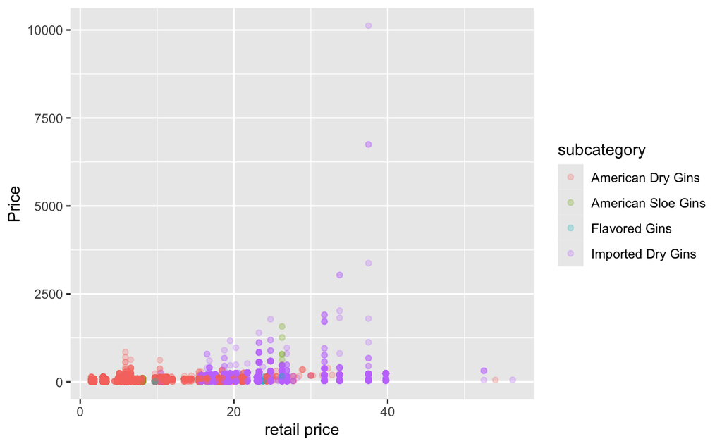

Selecting the county johnson as one instance of KNN analysis. Johnson has the highest bachelor degree ratio among all counties(0.543), and by inducing the gin subcategories and their retail prices, we expect to see some intercations of how the higher bachelor degree relating to different gin categories. Will people choose to buy more expensive gin when the bachelor degree ratio is higher than 0.2? From the plot, we could locate rough patterns that people may tend to buy higher standards of gin, and as retail prices increase, the gin consumptions increase. However, this increasing trend doesn’t mean that people consumes a lot on liquor.

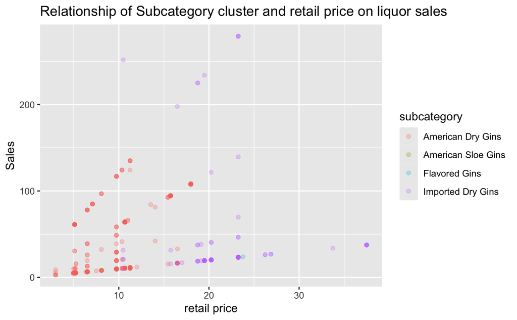

## Advantages and Challenges of Data Analysis in RStudio and Tableau

**Advantages**

There are some notable advantages of conducting data analysis in RStudio. One major advantage is that RStudio is really compatible with working in Github. Creating, maintaining, and formatting the README file in RStudio was quite simple since it functions practically like any other word processing software. This made it easy to embed images, add headers, and format the README report like a normal document. Another convenient aspect is that RStudio works well with reading in files from Github. RStudio adjusts the working directory to where the file that is trying to be pulled in is located. This means that anyone who clones our repo, including our data folder, can seamlessly run our analysis scripts. With Tableau, we can easily construct interactive dashboards and visualizations by dragging and dropping data fields into the canvas, all without having to write any code. This makes it perfect for exploratory analysis and quick insights because it enables rapid prototyping and iteration. Numerous data sources, including as databases, spreadsheets, cloud services, and big data platforms, are easily integrated with Tableau. As a result, we may connect to and evaluate data from several sources simultaneously.

**Disadvantages**

Getting used to version control in RStudio was a bit difficult for a group of beginners. Managing version conflicts on the README file was definitely challenging and we had to redo aspects of our report that disappeared as a result of version complications. An asset of RStudio was definitely being able to use different packages and libraries. However, familiarizing yourself with the packages that you need was challenging at times. This was relevant in a group project because people used different packages for their own analyses. Compared to other coding languages, Tableau offer fewer customization choices despite its extensive visualization capabilities. We run into problems while attempting to develop really intricate or bespoke representations. Large datasets and intricate computations also cause us to run into performance problems, especially when we are utilizing real-time connectivity to data sources. We have noticed that load times and refresh rates are slower, particularly on dashboards that are not as optimized.

# Conclusion

### Summary of analytic methodology

Linear regression analyses between gin sales on bachelor degree and high school graduation ratio

two-sample t test between higher/lower educational attainment level

### Limitations

A major limitation that we ran into as we were attempting the forecasting analyses was the lack of data. We were only provided with data from 2016 to 2017 which made it difficult for us to create a working forecasting model that we trusted and could include in our policy recommendation. Access to more time series data would allow us to expand on our forecasting analyses and strengthen our policy recommendation. Another related limitation is that the time series information that we did have access to was only for gin sales rather than all liquor sales. Again, having more data, this time in the form of all liquor sales and not just gin sales could strengthen our policy recommendation as the Director of Public Health is interested in all liquor sales and not solely gin sales.

When we explore the liquor sales in dollars and in volume on educational attainment level, it’s been a challenge to come with a proper method to analyze on how each variables connect to each other, and how to find the commonality for all counties’ educatioanl attainment and provide our policy recommendation on liquor consumption. The percentage of educational attainment is considered differently for each county, so manually defining high or low educational attainment may affect our judgment of the final results because there are no other relevant factors to rule out covariance.

In the future, it would be nice to expand this project to include city-related data as well. At this time the Director of Public Health is most concerned with county level data but it would be interesting to consult city level data and see how our analyses and conclusions differ.